# Basics of TenserFlow

### Tenser & setup of network & Model

A tenser is a N-dimensional array:

- For example:
  - A scaler value of X = 23 --- is a Rank 0 Tenser
  - While a vector Y = [1.0,1.2,1.5,14] --- has a Rank of 1
  - And a Matrix of L = [[1.2,1.3],[2.0,2,1,2.4],[3,3.5,4,4.5,5]] --- has a Rank of 2
  - Similarly a Cube of numbers C3 = [[[2],[4],[5]],[[6],[8],[9]],[[12],[15],[16]]] --- has a Rank of 3

Tenser have different data types for cmputational efficiency like:

```
* DT_FLOAT , tf.float32
* DT_FLOAT , tf.float64
* DT_INT , tf.int8
```

TenserFlow library will assing data type automatically, however declaring datatype is good practice as model will take optimum time trainingthen.

Tenserflow library uses computation using a dataflow graph i.e data format is in tensers and computation is guided by flow-graph.

> Any Tf program will have 2 discrete parts:

> ```
> +  Building a computaional graph ( operational steps arranged in graph of nodes)
> +  Running tensers on the computational graph (data is in tensers)
> ```

> Optimizer: Checks the magnitude of difference on the loss w.r.t each variable. i.e. Optimizer will update the variable in he direction such that loss minimizes.

Examples of Optimizers - Gradient Descent, Adam, AdaGrad etc.

### Types of Networks

#### FeedForward Networks

```
* Output at step t is independednt of output from step (t-1),(t-2) or (t+1).
* For example a univariate timeseries whose value at a point is not dependent on previous or future values.
```

#### Convolutional Neural Network

- Not discussed here

#### Recurrent Neural Network

It is short for “Recurrent Neural Network”, and is basically a neural network that can be used when your data is treated as a sequence, where the particular order of the data-points matter. More importantly, this sequence can be of arbitrary length. The most straight-forward example is perhaps a time-seriedems of numbers, where the task is to predict the next value given previous values. The input to the RNN at every time-step is the current value as well as a state vector which represent what the network has “seen” at time-steps before. This state-vector is the encoded memory of the RNN, initially set to zero. Great paper on this https://arxiv.org/pdf/1506.00019.pdf

> During Backpropogation there is possibility of Vanishing Gradient Problem.
> - i.e while calculating error at one point the weight and change in error ∆w both may be <<<<1. In such a scenario the gradient is lowered to the point of any reasonability , new weight ~ old weight.
> - Exploding gradient is exactly the opposite of this.

\begin{equation*} (Error) =(Actual Output - Predicted Output)^2 \end{equation*}

\begin{equation*} \ ∆w = d(Error)/d(Weight) * Learning Rate\\ \ w = w + ∆w\\ \end{equation*}

Exploding Gradient are handled well by:

```
* Setting up a threshold value called Clip Gradient
* Truncated BTT
* Adjust the learning rate - RMSprop
```

Vanishng Gradient is handled by below measures:

```
* ReLU activation function - (getting output 1 while calculating gradient)
* RMSProp - clip the gradient again once it goes out of a threshold value
* LSTM
```

#### Long Short Term Memory Network

Special type of RNN, capable of learning long-term dependencies. How LSTM works in steps:

```
+ Step 1 - Decides what information is going to be thrown away from the cell state
```

\begin{equation*} \ w_f = Weight\\ \ h(t-1) = Output From Previous Point\\ \ X_t = New Input\\ \ B_f = Bias\\ \ f_t = Forget Gate Layer \end{equation*}

\begin{align} f_t = \sigma (w_f[h(t-1),X_t]+B_f)\\ \end{align}

How LSTM works in steps:

```
+ Step 2 - What information to keep which is decided in 2 parts itself
* A sigmoid layer containing the input gate layer decides which values to be updated
* A tanh layer contains vector of new candidate values that would be added to the state
```

\begin{equation*} \ w_i = Weight\\ \ h(t-1) = Output From Previous Point\\ \ X_i = New Input\\ \ B_i = Bias\\ \ f_i = Forget Gate Layer \end{equation*}

\begin{align} i_t = \sigma (w_i[h(t-1),X_t]+B_i)\\ ~c_t = \tanh (w_c[h(t-1),X_c]+B_c)\\ \end{align}

How LSTM works in steps:

```
+ Step 3 - Combining old cell state C(t-1) into new cell state Ct.
* First we multiple old cell state C(t-1) by F_t.
* Then add (i_t * ~c_t) to the new candidate values scaled by how much ever it was decided to update each value state.
```

\begin{align} i_t = f_t * c(t-1) + (i_t * ~c_t)\\ \end{align}

How LSTM works in steps:

```
+ Step 4 - Last step, deciding what needs to be the output.
* We push cell state through tanh ( push values to be between -1 and 1)
* Multiply that by Sigmoid gate (to get revlevent outputs only)
```

\begin{align} o_t = \sigma (w_o[h(t-1),X_t]+B_o)\\ ~h_t = o_t * tanh(c_t)\\ \end{align}

## Running a simple Tf model on dummy data

```python
import keras
import tensorflow as tf
import numpy as np
import matplotlib.pyplot as plt
from keras.models import Sequential
from keras.layers import Dense
from keras.layers import LSTM
print(tf.__version__, "-- tf",
      np.__version__,"-- np",
      keras.__version__, "-- keras")
```

```
1.5.0 -- tf 1.14.1 -- np 2.0.8 -- keras
```

```python
#Creating the dummy data
data = np.array([ i for i in range(100)], dtype = float)
target = np.array([ i for i in range(50)], dtype = float)
```

```python
#Reshaping data to 3D
data = data.reshape((1, 1, 100))
target = target.reshape((1, 1, 50))
x_test=[i for i in range(100,200)]
x_test=np.array(x_test).reshape((1,1,100));
y_test=[i for i in range(101,151)]
y_test=np.array(y_test).reshape(1,1,50)
```

```python
#Modelling with tf.format data
model = Sequential()
model.add(LSTM(5, input_shape=(1, 100),return_sequences=True))
model.add(Dense(50))
model.compile(loss='mean_absolute_error', optimizer='adam',metrics=['accuracy'])
model.fit(data, target, nb_epoch=5000, batch_size=1, verbose=2,validation_data=(x_test, y_test))
```

[output not shown]

```
Train on 1 samples, validate on 1 samples
1s - loss: 24.4936 - acc: 0.0000e+00 - val_loss: 125.5290 - val_acc: 0.0000e+00
0s - loss: 24.4918 - acc: 0.0000e+00 - val_loss: 125.5273 - val_acc: 0.0000e+00
0s - loss: 24.4901 - acc: 0.0000e+00 - val_loss: 125.5256 - val_acc: 0.0000e+00
0s - loss: 24.4883 - acc: 0.0000e+00 - val_loss: 125.5240 - val_acc: 0.0000e+00
0s - loss: 24.4867 - acc: 0.0000e+00 - val_loss: 125.5223 - val_acc: 0.0000e+00
0s - loss: 24.4849 - acc: 0.0000e+00 - val_loss: 125.5206 - val_acc: 0.0000e+00
0s - loss: 24.4831 - acc: 0.0000e+00 - val_loss: 125.5189 - val_acc: 0.0000e+00
0s - loss: 24.4814 - acc: 0.0000e+00 - val_loss: 125.5172 - val_acc: 0.0000e+00
0s - loss: 24.4796 - acc: 0.0000e+00 - val_loss: 125.5155 - val_acc: 0.0000e+00
0s - loss: 24.4779 - acc: 0.0000e+00 - val_loss: 125.5138 - val_acc: 0.0000e+00
0s - loss: 24.4761 - acc: 0.0000e+00 - val_loss: 125.5122 - val_acc: 0.0000e+00
0s - loss: 24.4743 - acc: 0.0000e+00 - val_loss: 125.5105 - val_acc: 0.0000e+00
0s - loss: 24.4726 - acc: 0.0000e+00 - val_loss: 125.5088 - val_acc: 0.0000e+00
0s - loss: 24.4708 - acc: 0.0000e+00 - val_loss: 125.5071 - val_acc: 0.0000e+00
0s - loss: 24.4690 - acc: 0.0000e+00 - val_loss: 125.5054 - val_acc: 0.0000e+00
0s - loss: 24.4673 - acc: 0.0000e+00 - val_loss: 125.5037 - val_acc: 0.0000e+00
0s - loss: 24.4655 - acc: 0.0000e+00 - val_loss: 125.5020 - val_acc: 0.0000e+00
0s - loss: 24.4638 - acc: 0.0000e+00 - val_loss: 125.5003 - val_acc: 0.0000e+00
0s - loss: 24.4620 - acc: 0.0000e+00 - val_loss: 125.4986 - val_acc: 0.0000e+00
0s - loss: 24.4602 - acc: 0.0000e+00 - val_loss: 125.4969 - val_acc: 0.0000e+00
0s - loss: 24.4585 - acc: 0.0000e+00 - val_loss: 125.4952 - val_acc: 0.0000e+00
0s - loss: 24.4567 - acc: 0.0000e+00 - val_loss: 125.4935 - val_acc: 0.0000e+00
0s - loss: 24.4549 - acc: 0.0000e+00 - val_loss: 125.4918 - val_acc: 0.0000e+00
0s - loss: 24.4532 - acc: 0.0000e+00 - val_loss: 125.4902 - val_acc: 0.0000e+00
0s - loss: 24.4514 - acc: 0.0000e+00 - val_loss: 125.4885 - val_acc: 0.0000e+00
0s - loss: 24.4497 - acc: 0.0000e+00 - val_loss: 125.4868 - val_acc: 0.0000e+00
0s - loss: 24.4479 - acc: 0.0000e+00 - val_loss: 125.4851 - val_acc: 0.0000e+00
0s - loss: 24.4461 - acc: 0.0000e+00 - val_loss: 125.4834 - val_acc: 0.0000e+00
0s - loss: 24.4444 - acc: 0.0000e+00 - val_loss: 125.4817 - val_acc: 0.0000e+00
0s - loss: 24.4426 - acc: 0.0000e+00 - val_loss: 125.4800 - val_acc: 0.0000e+00
0s - loss: 24.4408 - acc: 0.0000e+00 - val_loss: 125.4783 - val_acc: 0.0000e+00
0s - loss: 24.4391 - acc: 0.0000e+00 - val_loss: 125.4766 - val_acc: 0.0000e+00
0s - loss: 24.4373 - acc: 0.0000e+00 - val_loss: 125.4749 - val_acc: 0.0000e+00
0s - loss: 24.4355 - acc: 0.0000e+00 - val_loss: 125.4732 - val_acc: 0.0000e+00
0s - loss: 24.4338 - acc: 0.0000e+00 - val_loss: 125.4715 - val_acc: 0.0000e+00
0s - loss: 24.4320 - acc: 0.0000e+00 - val_loss: 125.4698 - val_acc: 0.0000e+00
0s - loss: 24.4303 - acc: 0.0000e+00 - val_loss: 125.4681 - val_acc: 0.0000e+00
0s - loss: 24.4285 - acc: 0.0000e+00 - val_loss: 125.4664 - val_acc: 0.0000e+00
0s - loss: 24.4267 - acc: 0.0000e+00 - val_loss: 125.4647 - val_acc: 0.0000e+00
```

[output cut: 4946 more lines]

```
0s - loss: 16.5656 - acc: 0.0000e+00 - val_loss: 117.6105 - val_acc: 0.0000e+00
0s - loss: 16.5642 - acc: 0.0000e+00 - val_loss: 117.6091 - val_acc: 0.0000e+00
0s - loss: 16.5627 - acc: 0.0000e+00 - val_loss: 117.6076 - val_acc: 0.0000e+00
0s - loss: 16.5613 - acc: 0.0000e+00 - val_loss: 117.6062 - val_acc: 0.0000e+00
0s - loss: 16.5598 - acc: 0.0000e+00 - val_loss: 117.6047 - val_acc: 0.0000e+00
0s - loss: 16.5584 - acc: 0.0000e+00 - val_loss: 117.6033 - val_acc: 0.0000e+00
0s - loss: 16.5569 - acc: 0.0000e+00 - val_loss: 117.6018 - val_acc: 0.0000e+00
0s - loss: 16.5555 - acc: 0.0000e+00 - val_loss: 117.6004 - val_acc: 0.0000e+00
0s - loss: 16.5540 - acc: 0.0000e+00 - val_loss: 117.5989 - val_acc: 0.0000e+00
0s - loss: 16.5526 - acc: 0.0000e+00 - val_loss: 117.5975 - val_acc: 0.0000e+00
0s - loss: 16.5511 - acc: 0.0000e+00 - val_loss: 117.5961 - val_acc: 0.0000e+00
0s - loss: 16.5497 - acc: 0.0000e+00 - val_loss: 117.5947 - val_acc: 0.0000e+00
0s - loss: 16.5483 - acc: 0.0000e+00 - val_loss: 117.5932 - val_acc: 0.0000e+00
0s - loss: 16.5468 - acc: 0.0000e+00 - val_loss: 117.5918 - val_acc: 0.0000e+00
0s - loss: 16.5454 - acc: 0.0000e+00 - val_loss: 117.5903 - val_acc: 0.0000e+00
```

```
<keras.callbacks.History at 0x1c223eff60>
```

It is evident that on training after each epoch of data is fed, the model learns and loss is getting lowered. This is further made efficient by various optimizers.

```python
predict = model.predict(x_test)
```

## Running a RNN TF model on Binary Data & plotting loss at each epoch - via. Siraj Raval Tutorial

```python
#Hyperparameters
num_epochs = 100 #contain batches of data used in interation while training, for every epoch training will be done
total_series_length = 50000
truncated_backprop_length = 15
state_size = 4 #number of neuraons in the hidden layer
num_classes = 2 #as data is binary 1/0
echo_step = 3 #
batch_size = 5 #inside each epoch there are batches
num_batches = total_series_length//batch_size//truncated_backprop_length #
```

```python
#Generating data -- 50K samples of timeseries data with Binary nature
def generateData():
    x = np.array(np.random.choice(2,total_series_length, p=[.5,0.5]))
    #shifting the series by steps to the left ~ lag by 3
    y = np.roll(x, echo_step)
    y[0:echo_step] = 0
    x = x.reshape((batch_size, -1))
    y = y.reshape((batch_size, -1))
    #reshaping is required to put data through the placeholder - so it can be fed to the model
    #the reshaping takes the whole dataset and puts it into a matrix,
    #that later will be sliced up into these mini-batches.
    return(x,y)
```

```python
data = generateData()
print(data)
```

```
(array([[1, 0, 0, ..., 0, 1, 0],
       [1, 1, 1, ..., 1, 0, 1],
       [0, 0, 0, ..., 1, 0, 0],
       [0, 0, 1, ..., 0, 1, 0],
       [0, 1, 1, ..., 0, 1, 0]]), array([[0, 0, 0, ..., 0, 1, 0],
       [0, 1, 0, ..., 1, 1, 0],
       [1, 0, 1, ..., 0, 0, 0],
       [1, 0, 0, ..., 1, 1, 1],
       [0, 1, 0, ..., 1, 0, 0]]))
```

```python
#TensorFlow works by first building up a computational graph, that
#specifies what operations will be done. The input and output of this graph
#is typically multidimensional arrays, also known as tensors.
#The graph, or parts of it can then be executed iteratively.

#datatype, shape (5, 15) 2D array or matrix, batch size shape for later
batchX_placeholder = tf.placeholder(tf.float32,[batch_size, truncated_backprop_length])
batchY_placeholder = tf.placeholder(tf.int32, [batch_size, truncated_backprop_length])

init_state = tf.placeholder(tf.float32, [batch_size, state_size])
```

```python
#The weights and biases of the network are declared as TensorFlow variables,
#which makes them persistent across runs and enables them to be updated
#incrementally for each batch.
#3 layer recurrent net, one hidden state

#As there are 3 layers in the network there has to be 2 weights for the layers

#randomly initialize weights & not setting to 0 (optimum practice)
W = tf.Variable(np.random.rand(state_size+1, state_size), dtype=tf.float32)
b = tf.Variable(np.zeros((1, state_size)),dtype=tf.float32)

W2 = tf.Variable(np.random.rand(state_size, num_classes), dtype=tf.float32)
b2 = tf.Variable(np.zeros((1, num_classes)), dtype=tf.float32)
```

```python
#Unpack matrix into 1 D array

#Now it’s time to build the part of the graph that resembles the actual RNN computation,
#first we want to split the batch data into adjacent time-steps.

#Unpacks the given dimension of a rank-R tensor into rank-(R-1) tensors.
#so a bunch of arrays, 1 batch per time step
inputs_series = tf.unstack(batchX_placeholder, axis =1)
labels_series = tf.unstack(batchY_placeholder, axis =1)
```

```python
#Forward Pass
#State placeholder
current_state = init_state
state_series = []

for current_input in inputs_series:
    current_input = tf.reshape(current_input, [batch_size,1])
    input_and_state_concatenated = tf.concat([tf.cast(current_input,tf.float32),current_state],1) #tf.cast added
    #combining 2 tensors together
    next_state = tf.tanh(tf.matmul(input_and_state_concatenated, W) + b)
    #performing matrix multiplication and applying activation(squashing) function on the combined data & weights - then adding bias
    state_series.append(next_state)
    #appending new list with learned hidden state such that it stores them
    current_state = next_state

# Cannot convert a list containing a tensor of dtype <dtype: 'float32'> to <dtype: 'int32'> (Tensor is: <tf.Tensor 'Placeholder_5:0' shape=(5, 4) dtype=float32>)
# Tensors in list passed to 'values' of 'ConcatV2' Op have types [int32, float32] that don't all match.
#input_and_state_concatenated = tf.concat([tf.cast(current_input,tf.float32),current_state],1)
```

```python
#Backward Pass
#Calculate loss and minimize it
logits_series = [tf.matmul(state, W2) + b2 for state in state_series]
#apply softmax nonlinearity for output probability
predictions_series = [tf.nn.softmax(logits) for logits in logits_series]


#measure loss, calculate softmax again on logits, then compute cross entropy
#measures the difference between two probability distributions
#this will return A Tensor of the same shape as labels and of the same type as logits
#with the softmax cross entropy loss.

losses = [tf.nn.sparse_softmax_cross_entropy_with_logits(logits=logits_series, labels=labels_series)]
total_loss = tf.reduce_mean(losses)
train_step = tf.train.AdagradOptimizer(0.3).minimize(total_loss)

#the last line is adding the training functionality
#TensorFlow will perform back-propagation for us automatically.
#the computation graph is executed once for each mini-batch and the network-weights are updated incrementally.

#losses = [tf.nn.sparse_softmax_cross_entropy_with_logits(logits=logits_series, labels=labels_series)
```

```python
def plot(loss_list, predictions_series, batchX, batchY):
    plt.subplot(2, 3, 1)
    plt.cla()
    plt.plot(loss_list)

    for batch_series_idx in range(5):
        one_hot_output_series = np.array(predictions_series)[:, batch_series_idx, :]
        single_output_series = np.array([(1 if out[0] < 0.5 else 0) for out in one_hot_output_series])

        plt.subplot(2, 3, batch_series_idx + 2)
        plt.cla()
        plt.axis([0, truncated_backprop_length, 0, 2])
        left_offset = range(truncated_backprop_length)
        plt.bar(left_offset, batchX[batch_series_idx, :], width=1, color="blue")
        plt.bar(left_offset, batchY[batch_series_idx, :] * 0.5, width=1, color="red")
        plt.bar(left_offset, single_output_series * 0.3, width=1, color="green")

    plt.draw()
    plt.pause(0.0001)

#There is a visualization function so we can se what’s going on in the network as we train.
#It will plot the loss over the time, show training input.
#training output and the current predictions by the network on different sample series in a training batch.
```

```
WARNING:tensorflow:From /Users/Radhika/anaconda/lib/python3.6/site-packages/tensorflow/python/util/tf_should_use.py:118: initialize_all_variables (from tensorflow.python.ops.variables) is deprecated and will be removed after 2017-03-02.
Instructions for updating:
Use `tf.global_variables_initializer` instead.
```

```
New data, epoch 0
Step 0 Loss 0.8020551
Step 100 Loss 0.45300508
Step 200 Loss 0.017487813
Step 300 Loss 0.0065260846
Step 400 Loss 0.0047803484
Step 500 Loss 0.003431735
Step 600 Loss 0.0022448688
New data, epoch 1
Step 0 Loss 0.17772599
Step 100 Loss 0.0025714247
Step 200 Loss 0.0022522835
Step 300 Loss 0.0017413797
Step 400 Loss 0.0014698623
Step 500 Loss 0.0014084987
Step 600 Loss 0.0011035769
New data, epoch 2
Step 0 Loss 0.41770023
Step 100 Loss 0.0010533271
Step 200 Loss 0.0011154613
Step 300 Loss 0.00074992864
Step 400 Loss 0.00077894056
Step 500 Loss 0.00068403303
Step 600 Loss 0.00071259466
New data, epoch 3
Step 0 Loss 0.14671668
Step 100 Loss 0.0006392575
Step 200 Loss 0.000569233
Step 300 Loss 0.00047313853
Step 400 Loss 0.0005598769
Step 500 Loss 0.0005648945
Step 600 Loss 0.0004601496
New data, epoch 4
Step 0 Loss 0.12686309
Step 100 Loss 0.00054205814
Step 200 Loss 0.00049621833
Step 300 Loss 0.00049570075
Step 400 Loss 0.00045017203
Step 500 Loss 0.00041385792
Step 600 Loss 0.0004435334
```

[output cut: 745 more lines]

```
Step 0 Loss 0.08900835
Step 100 Loss 4.336478e-05
Step 200 Loss 3.265278e-05
Step 300 Loss 3.6117548e-05
Step 400 Loss 4.7645386e-05
Step 500 Loss 3.256532e-05
Step 600 Loss 3.6768863e-05
New data, epoch 99
Step 0 Loss 0.13094507
Step 100 Loss 3.6770612e-05
Step 200 Loss 5.496201e-05
Step 300 Loss 3.476361e-05
Step 400 Loss 4.1816813e-05
Step 500 Loss 3.3329674e-05
Step 600 Loss 4.2341464e-05
```

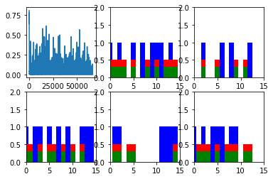

```python
#Step 3 Training the network
with tf.Session() as sess:
    #we stupidly have to do this everytime, it should just know
    #that we initialized these vars. v2 guys, v2..
    sess.run(tf.initialize_all_variables())
    #interactive mode
    plt.ion()
    #initialize the figure
    plt.figure()
    #show the graph
    plt.show()
    #to show the loss decrease
    loss_list = []

    for epoch_idx in range(num_epochs):
        #generate data at eveery epoch, batches run in epochs
        x,y = generateData()
        #initialize an empty hidden state
        _current_state = np.zeros((batch_size, state_size))

        print("New data, epoch", epoch_idx)
        #each batch
        for batch_idx in range(num_batches):
            #starting and ending point per batch
            #since weights reoccuer at every layer through time
            #These layers will not be unrolled to the beginning of time,
            #that would be too computationally expensive, and are therefore truncated
            #at a limited number of time-steps
            start_idx = batch_idx * truncated_backprop_length
            end_idx = start_idx + truncated_backprop_length

            batchX = x[:,start_idx:end_idx]
            batchY = y[:,start_idx:end_idx]

            #run the computation graph, give it the values
            #we calculated earlier
            _total_loss, _train_step, _current_state, _predictions_series = sess.run(
                [total_loss, train_step, current_state, predictions_series],
                feed_dict={
                    batchX_placeholder:batchX,
                    batchY_placeholder:batchY,
                    init_state:_current_state
                })

            loss_list.append(_total_loss)

            if batch_idx%100 == 0:
                print("Step",batch_idx, "Loss", _total_loss)
                plot(loss_list, _predictions_series, batchX, batchY)

plt.ioff()
plt.show()
```